# Tomey - Lab 11 Assignment - Resource Selection

# Re-running code from lab as a starting point

```r
require(terra)
require(tidyterra)
require(sf)
require(adehabitatHR)
require(adehabitatLT)
require(adehabitatHS)
require(tidyverse)
require(survival)
#Import landcover tif
land = rast('https://github.com/ValenteJJ/SpatialEcology/raw/main/Week10/panther_landcover.tif')

#Reclassify the landcover tif
classification = read.table('https://raw.githubusercontent.com/ValenteJJ/SpatialEcology/main/Week10/landcover%20reclass.txt', header=T)
land = classify(land, classification[,c(1,3)])
land = categories(land, value=unique(classification[,c(3,4)]))


#Import panther locations
panthers = st_read('/vsicurl/https://github.com/ValenteJJ/SpatialEcology/raw/main/Week10/panthers.shp') %>%
  mutate(CatID = as.factor(CatID))
#Calculate wet forest focal statistic (5 km radius)
wetForest = land
values(wetForest) = 0
wetForest[land %in% c(10,12)] = 1
probMatrix = focalMat(wetForest, 5000, type='circle', fillNA=FALSE)
wetFocal = focal(wetForest, probMatrix, fun='sum', na.rm=T)


#Calculate dry forest focal statistic (5 km radius)
dryForest = land
values(dryForest) = 0
dryForest[land %in% c(11, 13)] = 1
probMatrix = focalMat(dryForest, 5000, type='circle', fillNA=FALSE)
dryFocal = focal(dryForest, probMatrix, fun='sum', na.rm=T)

#Stack together
layers = c(land, wetFocal, dryFocal)
names(layers) = c('landcover', 'wetForest', 'dryForest')

#Recreate our used points object
use = terra::extract(layers, panthers) %>%
  data.frame() %>%
  mutate(CatID = as.factor(panthers$CatID)) %>%
  group_by(CatID, landcover) %>%
  summarise(n = n()) %>%
  ungroup() %>%
  arrange(landcover) %>%
  pivot_wider(names_from = landcover, values_from = n, values_fill=0) %>%
  data.frame()
row.names(use) = use$CatID
use$CatID = NULL

#Recreate our available points object for a type II design
set.seed(8)
randII = spatSample(land, size=1000, as.points=T)
randIILand = data.frame(randII)

availII = randIILand %>%
  group_by(Description2) %>%
  summarise(n = n()) %>%
  ungroup() %>%
  rename(landcover = Description2) %>%
  filter(!(is.na(landcover) | landcover=='Exotics')) %>%
  pivot_wider(names_from = landcover, values_from = n)
```

# Challenge 1 (5 points)

In the lab, we estimated Manly’s statistic (wi) values for a type II study design. We also fit a logistic regression for a type II study design. For this challenge, you’re going to explore the relationship between wi values and beta values from a logistic regression model. Below I have recreated the analysis for producing wi values. I’ve also reconstructed the dataset we used for fitting the logistic regression models (allCovs).

```r
#Recreating the wi analysis
selRatioII = widesII(u = use,
                     a = as.vector(as.matrix(availII)),
                     avknown = F,
                     alpha = 0.05)

#Recreating the dataset for logistic regression
useCovs = terra::extract(layers, panthers) %>%
  select(-ID) %>%
  mutate(use=1)
backCovs = terra::extract(layers, randII) %>%
  select(-ID) %>%
  mutate(use=0)
allCovs = rbind(useCovs, backCovs) %>%
  filter(!(is.na(landcover) | landcover=='Exotics')) %>%
  mutate(landcover = as.factor(as.character(landcover)))
```

### Logistic Regression (landcover - 1)

Fit a new logistic regression model where use is a function of landcover-1 (the -1 removes the intercept from the fitted model). Make sure this is the only covariate in the model. Exponentiate the coefficients from the fitted model.

```r
rsfInt = glm(use ~ landcover - 1, family=binomial(link=logit), data = allCovs)
expC = exp(coef(rsfInt))

expC
```

```
          landcoverBarren   landcovercoastalwetland         landcoverCropland     landcoverCypressSwamp
               1.57142857                0.14583333                0.34831461                5.00000000
      landcoverDryprairie  landcoverFreshwatermarsh    landcoverHardwoodSwamp        landcoverOpenWater
               1.12820513                0.79850746                3.43750000                0.10236220
landcoverPastureGrassland         landcoverPineland      landcoverScrub/Shrub     landcoverUplandForest
               0.58227848                2.67441860                1.16000000                2.86666667
           landcoverUrban
               0.07692308
```

### Comparison of Coefficients + WI Values

Compare them to the wi values calculated for each landcover type.

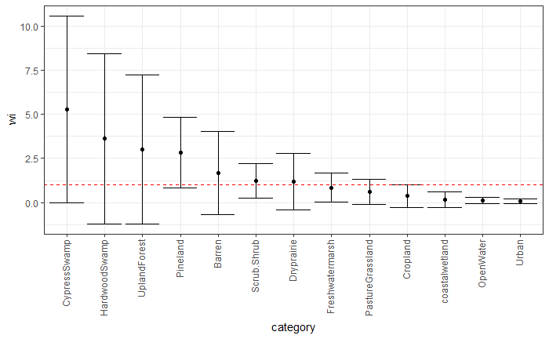

```r
tmp = data.frame('category' = names(selRatioII$wi),
                 'wi' = selRatioII$wi,
                 'ucl' = selRatioII$ICwiupper,
                 'lcl' = selRatioII$ICwilower) %>%
  arrange(desc(wi)) %>%
  mutate(category = factor(as.character(category), levels=category))

ggplot(tmp, aes(x=category, y=wi))+
  geom_point()+
  geom_errorbar(aes(ymin=lcl, ymax=ucl))+
  geom_hline(yintercept=1, col='red', linetype='dashed')+
  theme_bw()+
  theme(axis.text.x = element_text(angle=90, vjust=0.3, hjust=1))
```

```r
print('Wi')
```

```
[1] "Wi"
```

```r
selRatioII$wi
```

```
  coastalwetland         Cropland        OpenWater PastureGrassland            Urban           Barren
      0.15360566       0.36687836       0.10781769       0.61331156       0.08102276       1.65517932
      Dryprairie  Freshwatermarsh      Scrub.Shrub     CypressSwamp         Pineland    HardwoodSwamp
      1.18833387       0.84106466       1.22182328       5.26647966       2.81695424       3.62070477
    UplandForest
      3.01944834
```

**What do you notice? Explain the similarities and/or differences in how you would interpret the wi values and exponentiated coefficients.**

# Challenge 2 (5 points)

In the lab, we used the distribution of step lengths and turning angles to help us devise potential steps each individual could have taken at each point in time.

Code from Lab

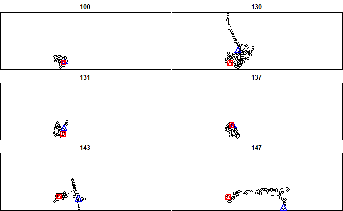

```r
# This function helps us tease out the date from the recorded DOY
substrRight = function(x, n){
  substr(x, nchar(x) - n+1, nchar(x))
}

#Here we're just creating a spatial object from our panthers sf object. Most of the code is dedicated to converting the DOY information to a real date.
panthersSp = panthers %>%
  mutate(Juldate = as.character(Juldate)) %>%
  mutate(date = as.numeric(substrRight(Juldate, 3))) %>%
  mutate(Date = as.Date(date, origin=as.Date("2006-01-01"))) %>%
  mutate(Date = as.POSIXct(Date, "%Y-%m-%d", tz='')) %>%
  as('Spatial')

#And this creates a trajectory object from the x-y coordinates and associated timestamps.
pantherLtraj = as.ltraj(xy=coordinates(panthersSp), date=panthersSp$Date, id=panthersSp$CatID, typeII=T)

plot(pantherLtraj)
```

### Histogram of Step Speeds (all Panthers)

Instead of step lengths, build a histogram representing the distribution of step speeds in km/hr.

```r
StepS = function(pantherdf) {
  # Calculate time differences in hours
  pantherdf$diff_time = c(0, diff(pantherdf$date))
  # Calculate step speed in km/hr
  pantherdf$step_speed = pantherdf$dist / pantherdf$diff_time / 1000
  return(pantherdf)
}

Pspeed = lapply(1:6, function(i) {
  pantherdf = pantherLtraj[[i]]
  pantherdf = StepS(pantherdf)
  return(pantherdf)
})

allPS = bind_rows(Pspeed, .id = "pantherID")
allPS
```

| pantherID | x | y | date | dx | dy | dist | dt | R2n | abs.angle | rel.angle | diff_time | step_speed |
| --- | --- | --- | --- | --- | --- | --- | --- | --- | --- | --- | --- | --- |
| 1 | 712916.8 | 250378.9 | 2006-01-04 18:00:00 | -12534.554554 | 2127.621125 | 12713.84401 | 172800 | 0.000000e+00 | 2.973454752 | NA | 0 | Inf |
| 1 | 700382.3 | 252506.5 | 2006-01-06 18:00:00 | 11993.392456 | 32.505914 | 11993.43651 | 259200 | 1.616418e+08 | 0.002710312 | -2.970744440 | 2 | 5.996718253 |
| 1 | 712375.7 | 252539.0 | 2006-01-09 18:00:00 | -1165.823295 | 371.560635 | 1223.60176 | 172800 | 4.959005e+06 | 2.833059470 | 2.830349159 | 3 | 0.407867252 |
| 1 | 711209.9 | 252910.5 | 2006-01-11 18:00:00 | -6739.711908 | -167.213663 | 6741.78589 | 172800 | 9.323242e+06 | -3.116787533 | 0.333338304 | 2 | 3.370892946 |
| 1 | 704470.1 | 252743.3 | 2006-01-13 18:00:00 | 132.560205 | 6246.645069 | 6248.05144 | 259200 | 7.693743e+07 | 1.549578487 | -1.616819287 | 2 | 3.124025721 |
| 1 | 704602.7 | 258990.0 | 2006-01-16 18:00:00 | 4196.490588 | -7709.035798 | 8777.22998 | 172800 | 1.432762e+08 | -1.072293574 | -2.621872061 | 3 | 2.925743328 |
| 1 | 708799.2 | 251280.9 | 2006-01-18 18:00:00 | 3059.579958 | -771.497868 | 3155.35077 | 172800 | 1.776877e+07 | -0.247008782 | 0.825284792 | 2 | 1.577675385 |
| 1 | 711858.8 | 250509.4 | 2006-01-20 18:00:00 | -10935.111911 | 7293.244806 | 13144.12767 | 259200 | 1.136557e+06 | 2.553389370 | 2.800398152 | 2 | 6.572063837 |
| 1 | 700923.7 | 257802.7 | 2006-01-23 18:00:00 | 5477.904572 | -3357.245336 | 6424.83733 | 172800 | 1.989496e+08 | -0.549829290 | -3.103218660 | 3 | 2.141612444 |
| 1 | 706401.6 | 254445.4 | 2006-01-25 18:00:00 | 4631.750301 | -3717.538684 | 5939.12491 | 172800 | 5.898591e+07 | -0.676336890 | -0.126507601 | 2 | 2.969562456 |

[output cut: 703 more lines]

[figure not shown]

```r
hist(allPS$step_speed, main = 'Distribution of Step Speeds (km/hr)',
     xlab = 'Step Speed (km/hr)', ylab = 'Frequency')
```

```r
NA
NA
```

**When and why might you choose to sample from a distribution of step speeds to calculate potential step lengths rather than drawing from the distribution of step lengths itself?** Sampling from a distribution of step speeds rather than step lengths to calculate potential step lengths may be useful when you are more interested in a behavior or movement that is related to the speed rather than distance. For example, if you are studying the energy expenditure, different speeds may represent varying levels of effort. Another example might be something related to the bird/nest studies we have discussed in class. If you are interested in the temporal relationship between movement and something like diurnal activity, the step speeds may serve as a metric more appropriate for calculating the potential step lengths rather than the step lengths. Ultimately, using the step speed may provide different and additional information to movement patterns.

# Challenge 3 (5 points)

Path straightness is a metric we can use to evaluate how tortuous of a path a tracked animal took from one point to another. We calculate straightness as the straight line distance between two points divided by the length of the path actually taken. The resulting straightness statistic takes a value between 0 and 1 where 1 indicates a straight line path and 0 represents an infinitely tortuous path.

```r
stepData = data.frame(st_coordinates(panthers)) %>%
  mutate(CatID = as.factor(panthers$CatID))
stepData
```

| X | Y | CatID |
| --- | --- | --- |
| 712916.8 | 250378.9 | 100 |
| 700382.3 | 252506.5 | 100 |
| 712375.7 | 252539.0 | 100 |
| 711209.9 | 252910.5 | 100 |
| 704470.1 | 252743.3 | 100 |
| 704602.7 | 258990.0 | 100 |
| 708799.2 | 251280.9 | 100 |
| 711858.8 | 250509.4 | 100 |
| 700923.7 | 257802.7 | 100 |
| 706401.6 | 254445.4 | 100 |

[output cut: 703 more lines]

```r
trajDf = ld(pantherLtraj)
```

### Straightness of Paths / Panther

For each of the 6 panthers, calculate the straightness of the path between the first and last point recorded. To do that, first calculate the numerator for each panther as the straight-line distance between the start and end points. HINT: the coordinates for each point are in UTMs (meters from the Equator and meters from the Prime Meridian). Next calculate the denominator for each panther. To do this, you can simply sum all of the step distances for that particular individual.Now divide the numerator by the denominator.

```r
pyth <- function(x1, y1, x2, y2) {
  sqrt((x2 - x1)^2 + (y2 - y1)^2)
}

unique(trajDf$id)
```

```
[1] "100" "130" "131" "137" "143" "147"
```

```r
# Levels: 100 130 131 137 143 147

p1 = trajDf[trajDf$id == 100, ]
s1 = p1[1, c('x', 'y')]
e1 = p1[nrow(p1), c('x', 'y')]
n1 = pyth(s1$x, s1$y, e1$x, e1$y)
d1 = sum(p1$dist, na.rm = TRUE)
STRTp1 = n1 / d1
STRTp1
```

```
[1] 0.001238409
```

```r
# 0.001238409

p2 = trajDf[trajDf$id == 130, ]
s2 = p2[1, c('x', 'y')]
e2 = p2[nrow(p2), c('x', 'y')]
n2 = pyth(s2$x, s2$y, e2$x, e2$y)
d2 = sum(p2$dist, na.rm = TRUE)
STRTp2 = n2 / d2
STRTp2
```

```
[1] 0.01967447
```

```r
# 0.01967447

p3 = trajDf[trajDf$id == 131, ]
s3 = p3[1, c('x', 'y')]
e3 = p3[nrow(p3), c('x', 'y')]
n3 = pyth(s3$x, s3$y, e3$x, e3$y)
d3 = sum(p3$dist, na.rm = TRUE)
STRTp3 = n3 / d3
STRTp3
```

```
[1] 0.009073811
```

```r
# 0.009073811


p4 = trajDf[trajDf$id == 137, ]
s4 = p4[1, c('x', 'y')]
e4 = p4[nrow(p4), c('x', 'y')]
n4 = pyth(s4$x, s4$y, e4$x, e4$y)
d4 = sum(p4$dist, na.rm = TRUE)
STRTp4 = n4 / d4
STRTp4
```

```
[1] 0.002275424
```

```r
# 0.002275424

p5 = trajDf[trajDf$id == 143, ]
s5 = p5[1, c('x', 'y')]
e5 = p5[nrow(p5), c('x', 'y')]
n5 = pyth(s5$x, s5$y, e5$x, e5$y)
d5 = sum(p5$dist, na.rm = TRUE)
STRTp5 = n5 / d5
STRTp5
```

```
[1] 0.04432766
```

```r
# 0.04432766

p6 = trajDf[trajDf$id == 147, ]
s6 = p6[1, c('x', 'y')]
e6 = p6[nrow(p6), c('x', 'y')]
n6 = pyth(s6$x, s6$y, e6$x, e6$y)
d6 = sum(p6$dist, na.rm = TRUE)
STRTp6 = n6 / d6
STRTp6
```

```
[1] 0.1561892
```

```r
# 0.1561892

STRTp1
```

```
[1] 0.001238409
```

```r
STRTp2
```

```
[1] 0.01967447
```

```r
STRTp3
```

```
[1] 0.009073811
```

```r
STRTp4
```

```
[1] 0.002275424
```

```r
STRTp5
```

```
[1] 0.04432766
```

```r
STRTp6
```

```
[1] 0.1561892
```

**Which panther took the most tortuous path? Which took the least tortuous path?** [p1] 0.001238409 [p2] 0.01967447 [p3] 0.009073811 [p4] 0.002275424 [p5] 0.04432766 [p6] 0.1561892

Based on a metric where 1 indicates a straight line path and 0 represents an infinitely tortuous path, panther 6 [147] took the least tortuous path (0.1561892) and panther 1 [100] took the most tortuous path (0.001238409).

# Challenge 4 (5 points)

For each panther, calculate the frequency with which locations were recorded as points per day. Plot path straightness as a function of frequency (there should be 6 points on this figure, one per panther).

### Frequency - locations/day

```r
panthersSp2 = panthers %>%
  mutate(Juldate = as.character(Juldate)) %>%
  mutate(date = as.numeric(substrRight(Juldate, 3))) %>%
  mutate(Date = as.Date(date, origin=as.Date("2006-01-01")))
panthersSp2
```

```
Simple feature collection with 713 features and 7 fields
Geometry type: POINT
Dimension:     XY
Bounding box:  xmin: 622483 ymin: 216222.9 xmax: 715910.6 ymax: 391339.8
Projected CRS: NAD_1983_HARN_Albers
First 10 features:
        X       Y CatID Juldate AgeClass                  geometry date       Date
1  513708 2900289   100    6004        A POINT (712916.8 250378.9)    4 2006-01-05
2  501212 2902716   100    6006        A POINT (700382.3 252506.5)    6 2006-01-07
3  513219 2902457   100    6009        A   POINT (712375.7 252539)    9 2006-01-10
4  512061 2902856   100    6011        A POINT (711209.9 252910.5)   11 2006-01-12
5  505310 2902853   100    6013        A POINT (704470.1 252743.3)   13 2006-01-14
6  505595 2909081   100    6016        A   POINT (704602.7 258990)   16 2006-01-17
7  509608 2901289   100    6018        A POINT (708799.2 251280.9)   18 2006-01-19
8  512652 2900445   100    6020        A POINT (711858.8 250509.4)   20 2006-01-21
9  501883 2907986   100    6023        A POINT (700923.7 257802.7)   23 2006-01-24
10 507285 2904504   100    6025        A POINT (706401.6 254445.4)   25 2006-01-26
```

```r
pDf = as.data.frame(panthersSp2)

pDf1 = pDf[pDf$CatID == 100, ]
u1 = unique(pDf1$Date)
u1 = length(u1)
t1 = nrow(pDf1)
f1 = t1 / u1

pDf2 = pDf[pDf$CatID == 130, ]
u2 = unique(pDf2$Date)
u2 = length(u2)
t2 = nrow(pDf2)
f2 = t2 / u2

pDf3 = pDf[pDf$CatID == 131, ]
u3 = unique(pDf3$Date)
u3 = length(u3)
t3 = nrow(pDf3)
f3 = t3 / u3

pDf4 = pDf[pDf$CatID == 137, ]
u4 = unique(pDf4$Date)
u4 = length(u4)
t4 = nrow(pDf4)
f4 = t4 / u4

pDf5 = pDf[pDf$CatID == 143, ]
u5 = unique(pDf5$Date)
u5 = length(u5)
t5 = nrow(pDf5)
f5 = t5 / u5

pDf6 = pDf[pDf$CatID == 147, ]
u6 = unique(pDf6$Date)
u6 = length(u6)
t6 = nrow(pDf6)
f6 = t6 / u6


u = unique(pDf$Date)
u = length(u)
# u = 150

fa = t1/ 150
fb = t2/ 150
fc = t3/ 150
fd = t4/ 150
fe = t5/ 150
ff = t6/ 150

f1
```

```
[1] 1
```

```r
f2
```

```
[1] 1
```

```r
f3
```

```
[1] 1
```

```r
f4
```

```
[1] 1
```

```r
f5
```

```
[1] 1
```

```r
f6
```

```
[1] 1
```

```r
fa
```

```
[1] 0.8466667
```

```r
fb
```

```
[1] 0.5666667
```

```r
fc
```

```
[1] 0.7866667
```

```r
fd
```

```
[1] 0.8733333
```

```r
fe
```

```
[1] 0.86
```

```r
ff
```

```
[1] 0.82
```

### Path Straightness X Frequency Plot

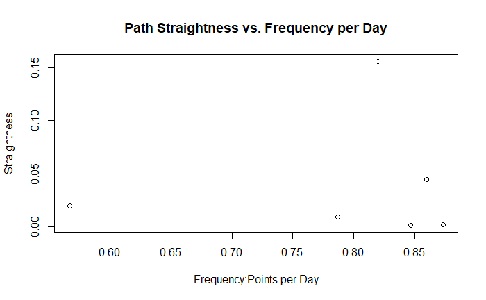

```r
frequency = c(0.8466667, 0.5666667, 0.7866667, 0.8733333, 0.86, 0.82)
straight = c(0.001238409, 0.01967447, 0.009073811, 0.002275424, 0.04432766, 0.1561892)


plot(frequency, straight,
     xlab = "Frequency:Points per Day",
     ylab = "Straightness",
     main = "Path Straightness vs. Frequency per Day")
```

**What relationship do you notice between these two variables, and why might that pattern be occurring?** There does not appear to be a strong relationship, but I am not sure if my calculations for these metrics are correct (sorry!). I would think that as the frequency in points per day increases, the straightness would decrease. This could be related to barriers to movement, resource selection, and previous area nagivation suggesting habitat use. However, this is difficult to definitively say with such a wide range of drivers to movements in the current panther study.